# Project 2: Linear Regression

36-600 HeathvonnStyles

Fall 2023

The goal of this project is to use linear regression to model flight delays as a function of other variables.

Your `HTML` file (generated by knitting an `R Markdown` source file) should be uploaded to Canvas by Friday, November 3rd, at 11:59 PM. As was the case for Project 1, there is no limit on the length here, but concision is a virtue. (There will be no lab on Tuesday the 31st, and the lab for Thursday the 2nd will have a delayed due date. This should provide you the necessary time to complete the project.)

## Data

You will examine the dataset `flightDelay2.csv`, which you will find in the `DATA` directory on `Canvas`.

The response variable is `ARR_DELAY`, the delay in arrival, in minutes. Your goal is inference, but what that really means is that you will at least check for multicollinearity, compute variance-inflation factors, and try out both PCA and PC regression.

The (possible) predictor variables are the following:

| name | description |
| --- | --- |
| YEAR |  |
| MONTH |  |
| DAY_OF_MONTH |  |
| DEP_TIME | Actual departure time (local time, hhmm). |
| DEP_DELAY | Difference in minutes between scheduled and actual departure time. Early departures show negative numbers. |
| TAXI_OUT | Time taken to taxi out to the runway, in minutes. |
| WHEELS_OFF | Time the flight took off (local time, hhmm). |
| WHEELS_ON | Time the flight landed (local time, hhmm). |
| TAXI_IN | Time taken to taxi in to the gate, in minutes. |
| ARR_TIME | Actual arrival time (local time, hhmm). |
| CANCELLED | 1 if the flight was cancelled. |
| DIVERTED | 1 if the flight was diverted. |
| ACTUAL_ELAPSED_TIME | Elapsed time of flight, in minutes. |
| DISTANCE | Distance between origin and destination airports, in miles. |
| CARRIER_DELAY | Length of delay caused by the airline (e.g. maintenance, waiting for crew, cleaning the plane), in minutes. Note that if the flight was not delayed, these fields will be blank. |
| WEATHER_DELAY | Length of delay caused by weather, in minutes. |
| NAS_DELAY | Length of delay caused by the National Airspace System, including air traffic control, in minutes. |
| SECURITY_DELAY | Length of delay caused by a security problem, such as evacuation of a terminal or excessive security lines, in minutes. |
| LATE_AIRCRAFT_DELAY | Length of delay caused because the aircraft arrived late from its previous airport, in minutes. |

The file will contain one or more unimportant variables that you will want to remove.

It also contains missing data! You should not remove any columns based on “missingness” of data, but only rows.

To remove all rows that have any missing data:

```
w <- complete.cases(df)
df <- df[w,]
```

Comment on the number of rows that are removed! (How many rows were there originally, and how many after you ran `complete.cases()`?)

Make good and principled choices…don’t worry about perfection. **There is no perfection here.** (There really isn’t. These data are messy.)

## Expectations

Your report should include the following elements:

- A description of the data (sample size, number of variables), and a list of removed variables.
- Concise EDA, including the identification and removal of proposed outliers (if there are any) and, potentially, the transformation of the response variable (but see below first). (Note: always try transformations first before identifying and removing outliers…that lonely data point in a skew distribution may look fine after a transformation is performed.) You can, if you wish, transform any predictor variables that are highly skew, but this is not required. Also, create a correlation plot and comment on the possibility of multicollinearity in the predictor variables. (One last note: the number of data is large, so if you create scatter plots, randomly sample some much smaller number of points to plot.)
- A description of how you split the data into training and test sets.
- An analysis of the full dataset with linear regression, with comments on the output (does the fit appear to be good?). Provide the mean-squared error and the predicted response vs. observed response diagnostic plot. Comment on the value of adjusted $R^2$: is the linear model useful, or might other models perform better? Also, realize that the response variable needs to be transformed if and only if (a) the *residuals* of the fit are not normally distributed *and* (b) you wish to do inference using the hypothesis test output from `lm()`. To plot the residuals, find the difference between the observed test-set response values and the predicted test-set response values, and make a histogram: does this plot look normal?
- Computation of variance-inflation factors. Comment if it appears that there is substantial multicollinearity, or not. Identify the potentially problematic variables (just list them). Do not remove variables with high vif factors, if there are any…just focus on variable selection via best-subset selection.
- A best-subset-selection analysis of the dataset. Which predictor variables are important for predicting flight delays? Compute the MSE for the `BestModel` and compare it to the MSE for the full set of predictors. (And remember: you need to change the name of the response variable to `y` before running BSS!)

```
w <- which(names(df)=="ARR_DELAY")
y <- df[,w]
df <- df[,-w]
df <- data.frame(df,"y"=y)
```

- Do a simple PCA analysis on the predictors with the goal of determining the “true” dimensionality of the predictor variables. Select some number of PCs to keep (while being sure to indicate what criterion you used). Run linear regression on these PCs and compute the test-set MSE, and show how it compares with the full-set MSE and the BSS MSE. There is no need to comment on *how* the original predictors map to PC space…just pick a suitable number of PCs and proceed directly to regression.

```r
df <- read.csv("flightDelay2.csv")
```

```
## 'data.frame':    34314 obs. of  21 variables:
##  $ YEAR               : int  2016 2016 2016 2016 2016 2016 2016 2016 2016 2016 ...
##  $ MONTH              : int  12 12 12 12 12 12 12 12 12 12 ...
##  $ DAY_OF_MONTH       : int  1 2 4 5 6 7 8 9 11 12 ...
##  $ DEP_TIME           : int  1646 1640 1650 1641 1646 1642 1649 1636 1732 1640 ...
##  $ DEP_DELAY          : int  1 -5 5 -4 1 -3 4 -9 47 -5 ...
##  $ TAXI_OUT           : int  20 13 29 36 15 11 11 17 14 8 ...
##  $ WHEELS_OFF         : int  1706 1653 1719 1717 1701 1653 1700 1653 1746 1648 ...
##  $ WHEELS_ON          : int  1822 1803 1833 1831 1813 1801 1811 1809 1906 1800 ...
##  $ TAXI_IN            : int  4 3 12 8 4 6 4 3 3 3 ...
##  $ ARR_TIME           : int  1826 1806 1845 1839 1817 1807 1815 1812 1909 1803 ...
##  $ ARR_DELAY          : int  4 -16 23 17 -5 -15 -7 -10 47 -19 ...
##  $ CANCELLED          : int  0 0 0 0 0 0 0 0 0 0 ...
##  $ DIVERTED           : int  0 0 0 0 0 0 0 0 0 0 ...
##  $ ACTUAL_ELAPSED_TIME: int  100 86 115 118 91 85 86 96 97 83 ...
##  $ DISTANCE           : int  550 550 550 550 550 550 550 550 550 550 ...
##  $ CARRIER_DELAY      : int  0 0 0 0 0 0 0 0 0 0 ...
##  $ WEATHER_DELAY      : int  0 0 0 0 0 0 0 0 0 0 ...
##  $ NAS_DELAY          : int  0 0 18 17 0 0 0 0 0 0 ...
##  $ SECURITY_DELAY     : int  0 0 0 0 0 0 0 0 0 0 ...
##  $ LATE_AIRCRAFT_DELAY: int  0 0 5 0 0 0 0 0 47 0 ...
##  $ X                  : logi  NA NA NA NA NA NA ...
```

```
Here the dataframe is examined to locate any missing values. The X column of the datafram appears to have NA values and should inspected further and possibly removed.
```

```
##   YEAR MONTH DAY_OF_MONTH DEP_TIME DEP_DELAY TAXI_OUT WHEELS_OFF WHEELS_ON
## 1 2016    12            1     1646         1       20       1706      1822
## 2 2016    12            2     1640        -5       13       1653      1803
## 3 2016    12            4     1650         5       29       1719      1833
## 4 2016    12            5     1641        -4       36       1717      1831
## 5 2016    12            6     1646         1       15       1701      1813
## 6 2016    12            7     1642        -3       11       1653      1801
##   TAXI_IN ARR_TIME ARR_DELAY CANCELLED DIVERTED ACTUAL_ELAPSED_TIME DISTANCE
## 1       4     1826         4         0        0                 100      550
## 2       3     1806       -16         0        0                  86      550
## 3      12     1845        23         0        0                 115      550
## 4       8     1839        17         0        0                 118      550
## 5       4     1817        -5         0        0                  91      550
## 6       6     1807       -15         0        0                  85      550
##   CARRIER_DELAY WEATHER_DELAY NAS_DELAY SECURITY_DELAY LATE_AIRCRAFT_DELAY  X
## 1             0             0         0              0                   0 NA
## 2             0             0         0              0                   0 NA
## 3             0             0        18              0                   5 NA
## 4             0             0        17              0                   0 NA
## 5             0             0         0              0                   0 NA
## 6             0             0         0              0                   0 NA
```

```r
head(df$X)
```

```
## [1] NA NA NA NA NA NA
```

[output not shown]

```
## Rows present before removing rows that contain missing data: 34314
```

```
## Total rows in dataframe after removing rows that contain missing data: 33307
```

```
1007 rows were dropped after locating rows which contain missing values. This is not a substantial drop of data and should not have a major impact on the results.
```

```
## [1] FALSE
```

```
##   YEAR MONTH DAY_OF_MONTH DEP_TIME DEP_DELAY TAXI_OUT WHEELS_OFF WHEELS_ON
## 1 2016    12            1     1646         1       20       1706      1822
## 2 2016    12            2     1640        -5       13       1653      1803
## 3 2016    12            4     1650         5       29       1719      1833
## 4 2016    12            5     1641        -4       36       1717      1831
## 5 2016    12            6     1646         1       15       1701      1813
## 6 2016    12            7     1642        -3       11       1653      1801
##   TAXI_IN ARR_TIME ARR_DELAY CANCELLED DIVERTED ACTUAL_ELAPSED_TIME DISTANCE
## 1       4     1826         4         0        0                 100      550
## 2       3     1806       -16         0        0                  86      550
## 3      12     1845        23         0        0                 115      550
## 4       8     1839        17         0        0                 118      550
## 5       4     1817        -5         0        0                  91      550
## 6       6     1807       -15         0        0                  85      550
##   CARRIER_DELAY WEATHER_DELAY NAS_DELAY SECURITY_DELAY LATE_AIRCRAFT_DELAY
## 1             0             0         0              0                   0
## 2             0             0         0              0                   0
## 3             0             0        18              0                   5
## 4             0             0        17              0                   0
## 5             0             0         0              0                   0
## 6             0             0         0              0                   0
```

```r
df1_cor = cor(df1)
```

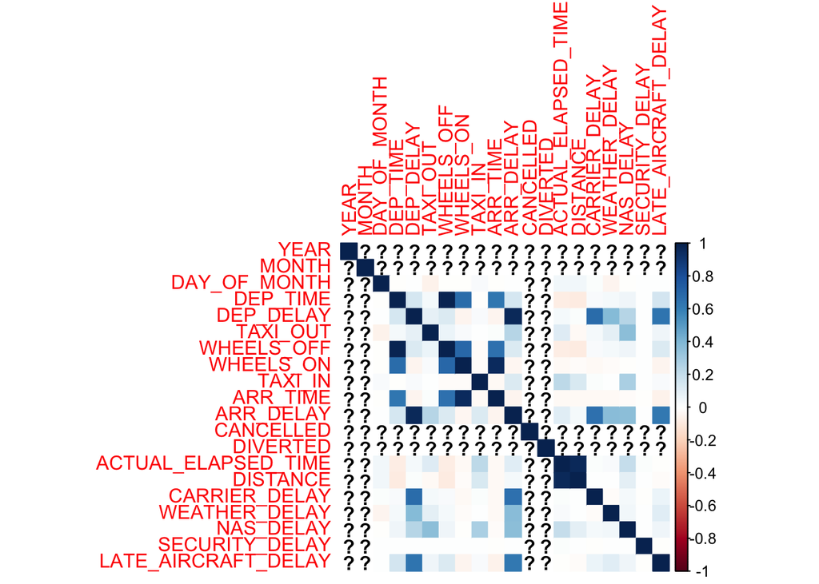

```r
corrplot(df1_cor, method="color")
```

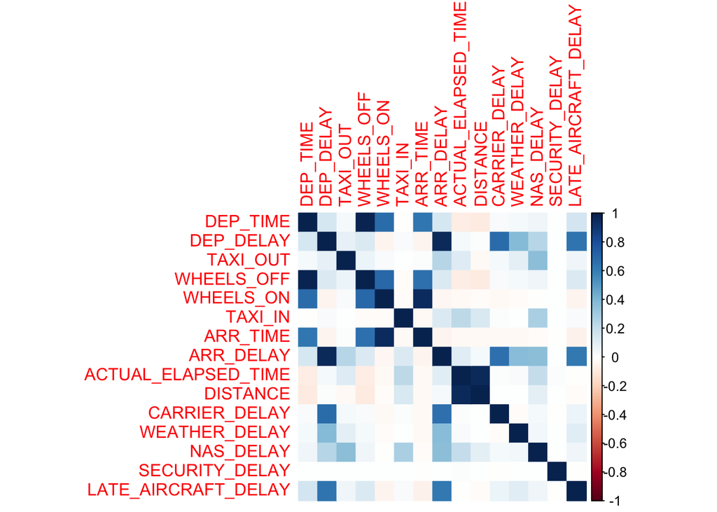

```
Predictor variables:MONTH,YEAR,CANCELLED, DIVERTED,DAY_OF_MONTH, were shown to have no correlation to the dataset based upon the above correlation plot were removed.
```

```r
df2 <- select(df1,-MONTH, -YEAR, -CANCELLED, -DIVERTED, -DAY_OF_MONTH)
df2_cor = cor(df2)
corrplot(df2_cor, method="color")
```

```r
z_scores <- scale(df2)
potential_outliers <- abs(z_scores) > 3

head(potential_outliers)
```

```
##   DEP_TIME DEP_DELAY TAXI_OUT WHEELS_OFF WHEELS_ON TAXI_IN ARR_TIME ARR_DELAY
## 1    FALSE     FALSE    FALSE      FALSE     FALSE   FALSE    FALSE     FALSE
## 2    FALSE     FALSE    FALSE      FALSE     FALSE   FALSE    FALSE     FALSE
## 3    FALSE     FALSE    FALSE      FALSE     FALSE   FALSE    FALSE     FALSE
## 4    FALSE     FALSE    FALSE      FALSE     FALSE   FALSE    FALSE     FALSE
## 5    FALSE     FALSE    FALSE      FALSE     FALSE   FALSE    FALSE     FALSE
## 6    FALSE     FALSE    FALSE      FALSE     FALSE   FALSE    FALSE     FALSE
##   ACTUAL_ELAPSED_TIME DISTANCE CARRIER_DELAY WEATHER_DELAY NAS_DELAY
## 1               FALSE    FALSE         FALSE         FALSE     FALSE
## 2               FALSE    FALSE         FALSE         FALSE     FALSE
## 3               FALSE    FALSE         FALSE         FALSE     FALSE
## 4               FALSE    FALSE         FALSE         FALSE     FALSE
## 5               FALSE    FALSE         FALSE         FALSE     FALSE
## 6               FALSE    FALSE         FALSE         FALSE     FALSE
##   SECURITY_DELAY LATE_AIRCRAFT_DELAY
## 1          FALSE               FALSE
## 2          FALSE               FALSE
## 3          FALSE               FALSE
## 4          FALSE               FALSE
## 5          FALSE               FALSE
## 6          FALSE               FALSE
```

[output not shown]

```r
df3 <- df2 %>%  filter(!row_number() == 36)
```

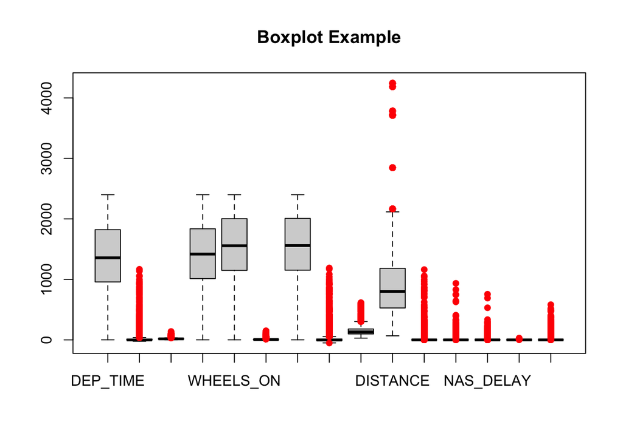

```r
boxplot(df3, main="Boxplot Example", outpch = 16, outcol = "red")
```

```r
par(cex.axis=0.2)

outliers <- boxplot(df3, plot=FALSE)$out

head(outliers)
```

```
## [1]  47  90  58 107  94  50
```

```
Using boxplot on the dataset allow for identification of outliers which are displayed in red above.25685 entries have been identified as oultiers.
```

```r
set.seed(505)

sample <- sample(nrow(scale(df3)), round(0.7*nrow(scale(df3))))
df.train  <- df3[sample, ]
df.test   <- df3[-sample, ]

lm.out <- lm(ARR_DELAY ~. , data = df.train)


summary(lm.out)
```

```
##
## Call:
## lm(formula = ARR_DELAY ~ ., data = df.train)
##
## Residuals:
##     Min      1Q  Median      3Q     Max
## -37.414  -3.842   0.417   4.248  74.384
##
## Coefficients:
##                       Estimate Std. Error  t value Pr(>|t|)
## (Intercept)         -2.353e+01  2.040e-01 -115.345  < 2e-16 ***
## DEP_TIME             2.278e-04  4.664e-04    0.488  0.62522
## DEP_DELAY            6.111e-01  4.846e-03  126.098  < 2e-16 ***
## TAXI_OUT             3.574e-01  6.324e-03   56.514  < 2e-16 ***
## WHEELS_OFF          -3.860e-04  4.715e-04   -0.819  0.41297
## WHEELS_ON            1.341e-03  2.810e-04    4.773 1.82e-06 ***
## TAXI_IN              2.357e-01  7.818e-03   30.149  < 2e-16 ***
## ARR_TIME            -6.900e-04  2.616e-04   -2.638  0.00835 **
## ACTUAL_ELAPSED_TIME  2.858e-01  2.946e-03   97.025  < 2e-16 ***
## DISTANCE            -3.635e-02  3.887e-04  -93.508  < 2e-16 ***
## CARRIER_DELAY        3.974e-01  5.113e-03   77.727  < 2e-16 ***
## WEATHER_DELAY        3.828e-01  5.652e-03   67.725  < 2e-16 ***
## NAS_DELAY            4.493e-01  5.109e-03   87.954  < 2e-16 ***
## SECURITY_DELAY       4.350e-01  1.592e-01    2.732  0.00629 **
## LATE_AIRCRAFT_DELAY  4.007e-01  5.297e-03   75.634  < 2e-16 ***
## ---
## Signif. codes:  0 '***' 0.001 '**' 0.01 '*' 0.05 '.' 0.1 ' ' 1
##
## Residual standard error: 6.373 on 23299 degrees of freedom
## Multiple R-squared:  0.9845, Adjusted R-squared:  0.9844
## F-statistic: 1.054e+05 on 14 and 23299 DF,  p-value: < 2.2e-16
```

```r
adjusted_r_squared <- summary(lm.out)$adj.r.squared

cat("Adjusted R Squared:", summary(lm.out)$adj.r.squared )
```

```
## Adjusted R Squared: 0.9844468
```

[output not shown]

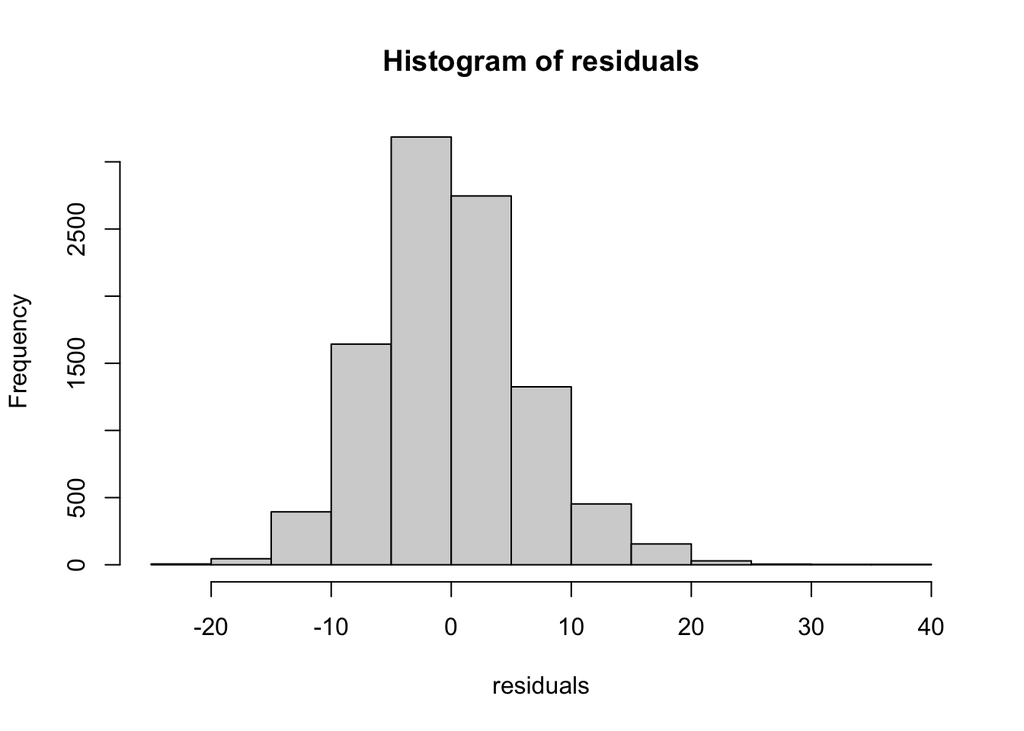

```
The histogram of residuals appears to be slightly right skewed.
```

```r
predicted_test_resp <- predict(lm.out,newdata=df.test)
residuals <- predicted_test_resp-df.test$ARR_DELAY

hist(residuals)
```

```r
vif(lm.out)
```

```
##            DEP_TIME           DEP_DELAY            TAXI_OUT          WHEELS_OFF
##           28.536993           32.065508            1.670726           29.392163
##           WHEELS_ON             TAXI_IN            ARR_TIME ACTUAL_ELAPSED_TIME
##           12.113095            1.300767           10.809747           24.611538
##            DISTANCE       CARRIER_DELAY       WEATHER_DELAY           NAS_DELAY
##           23.370954           15.135942            4.173353            2.925572
##      SECURITY_DELAY LATE_AIRCRAFT_DELAY
##            1.001458           10.649282
```

[output not shown]

```r
 mse.full <- mean(residuals^2)
 cat("mean-squared error:", mse.full)
```

```
## mean-squared error: 40.63176
```

```r
suppressMessages(library(bestglm))

w <- which(names(df3)=="ARR_DELAY")
y <- df3[,w]
df.train <- df3[,-w]
df.train <- data.frame(df3,"y"=y)


bg.out <- bestglm(df.train,family=gaussian,IC="BIC")
bg.out$BestModel
```

```
##
## Call:
## lm(formula = y ~ ., data = data.frame(Xy[, c(bestset[-1], FALSE),
##     drop = FALSE], y = y))
##
## Coefficients:
##         (Intercept)             DEP_TIME            DEP_DELAY
##          -1.311e-13            1.268e-18            4.756e-15
##            TAXI_OUT              TAXI_IN             ARR_TIME
##           4.704e-15            3.999e-15           -2.440e-18
##           ARR_DELAY  ACTUAL_ELAPSED_TIME             DISTANCE
##           1.000e+00            1.459e-17           -1.631e-18
##       CARRIER_DELAY
##           5.208e-19
```

```r
vif(bg.out$BestModel)
```

```
##            DEP_TIME           DEP_DELAY            TAXI_OUT             TAXI_IN
##            1.815948           46.249612            1.853112            1.349918
##            ARR_TIME           ARR_DELAY ACTUAL_ELAPSED_TIME            DISTANCE
##            1.757991           49.678216           34.685384           32.184275
##       CARRIER_DELAY
##            1.893358
```

```r
resp.pred <- predict(bg.out$BestModel,newdata=df.test)
cat("mean-squared error:",mean((resp.pred-df.test$ARR_DELAY)^2))
```

```
## mean-squared error: 1.964655e-27
```

[output not shown]

```r
head(df3)
```

```
##   DEP_TIME DEP_DELAY TAXI_OUT WHEELS_OFF WHEELS_ON TAXI_IN ARR_TIME ARR_DELAY
## 1     1646         1       20       1706      1822       4     1826         4
## 2     1640        -5       13       1653      1803       3     1806       -16
## 3     1650         5       29       1719      1833      12     1845        23
## 4     1641        -4       36       1717      1831       8     1839        17
## 5     1646         1       15       1701      1813       4     1817        -5
## 6     1642        -3       11       1653      1801       6     1807       -15
##   ACTUAL_ELAPSED_TIME DISTANCE CARRIER_DELAY WEATHER_DELAY NAS_DELAY
## 1                 100      550             0             0         0
## 2                  86      550             0             0         0
## 3                 115      550             0             0        18
## 4                 118      550             0             0        17
## 5                  91      550             0             0         0
## 6                  85      550             0             0         0
##   SECURITY_DELAY LATE_AIRCRAFT_DELAY
## 1              0                   0
## 2              0                   0
## 3              0                   5
## 4              0                   0
## 5              0                   0
## 6              0                   0
```

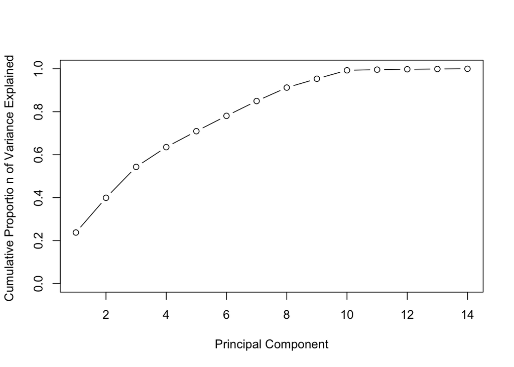

```
The true dimensionality is found to be 10 based on the graph above, where adding PCA components levels off.
```

```r
predictor_variables <- c("DEP_TIME","DEP_DELAY","TAXI_OUT","WHEELS_OFF","WHEELS_ON","TAXI_IN", "ARR_TIME", "ACTUAL_ELAPSED_TIME","DISTANCE","CARRIER_DELAY","WEATHER_DELAY","NAS_DELAY", "SECURITY_DELAY","LATE_AIRCRAFT_DELAY")
predictors <- df3[predictor_variables]

pca.out <- prcomp(predictors,scale=TRUE)
pr.var = pca.out$sdev^2

pve = pr.var/sum(pr.var)

plot ( cumsum( pve ) , xlab =" Principal Component " , ylab ="Cumulative Proportio n of Variance Explained " , ylim = c (0,1) ,
type = 'b')
```

```r
n <- 10

df4 <- data.frame(pca.out$x[, 1:n])
s <- sample(nrow(df), round(0.7*nrow(df)))

pc.train <- df4[s, ]
pc.test <- df4[-s, ]

lm.out <- lm(ARR_DELAY ~ ., data = cbind(pc.train, ARR_DELAY = df3$ARR_DELAY[s]))
lm.pred <- predict(lm.out, newdata = cbind(pc.test, ARR_DELAY = df3$ARR_DELAY[-s]))

mse <- mean((df3$ARR_DELAY[-s] - lm.pred)^2)
mse
```

```
## [1] 56.05553
```

```r
length(df$ARR_DELAY)
```

```
## [1] 34314
```